# STAT-S 681 midterm: instructions and distribution reference

**How this exam works.** The exam has four parts, two questions for each part, each part corresponding to something I want you to be able to do. Your goal is to convince me that you can do what each part describes. A larger number of correct, well-reasoned answers will make me more convinced; an answer that shows a serious misunderstanding could make me less convinced. If you don’t get to a question, that is not necessarily fatal, but you should try to do all of them and make sure you don’t entirely skip any of the four parts.

## Distribution reference

These are the distributions used in the questions.

| Distribution | Possible values | Parameters | Common use |
| --- | --- | --- | --- |
| $\operatorname{Bernoulli}(p)$ | $0$ or $1$ | $p$: probability of a 1 | one yes/no trial |
| $\operatorname{Binomial}(n,p)$ | $0,1,\ldots,n$ | $n$: number of trials; $p$: success probability of each trial | number of successes in $n$ independent trials |
| $\operatorname{Poisson}(\lambda)$ | $0,1,2,\ldots$ | $\lambda>0$: the average count (also the variance) | number of events in a fixed period, when events happen independently at a constant rate |
| $\operatorname{Normal}(\mu,\sigma^2)$ | any real number | $\mu$: mean; $\sigma^2$: variance ($\sigma$: standard deviation) | symmetric noise, such as measurement error |
| $\operatorname{Uniform}(a,b)$ | between $a$ and $b$ | $a$, $b$: endpoints | equally likely anywhere in a range |
| $\operatorname{Beta}(a,b)$ | between $0$ and $1$ | $a,b>0$; the average is $a/(a+b)$, and for a fixed average, larger $a+b$ gives less variable draws | a random probability or proportion |

The plots below show the probabilities (for distributions on whole numbers) or the density (for continuous distributions) of several members of each family. Within a row, the panels share a horizontal axis.

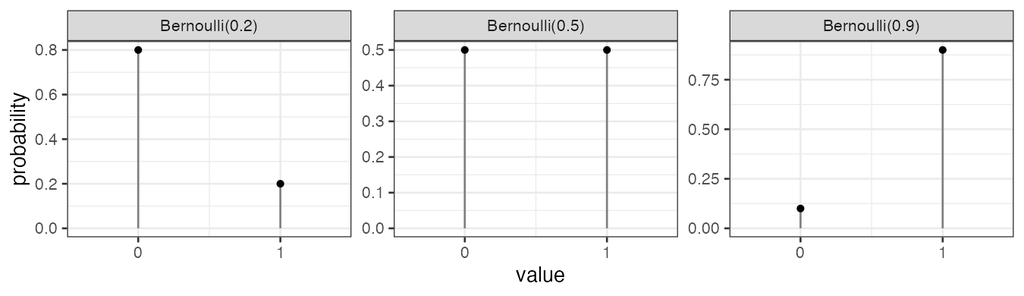

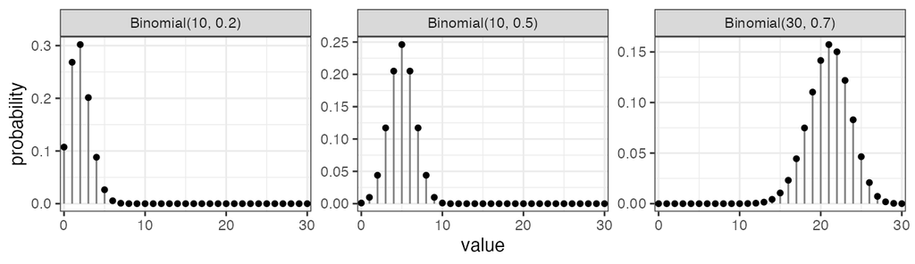

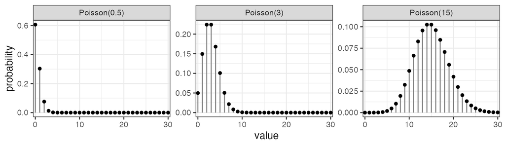

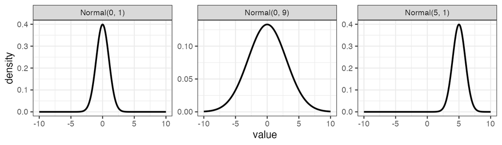

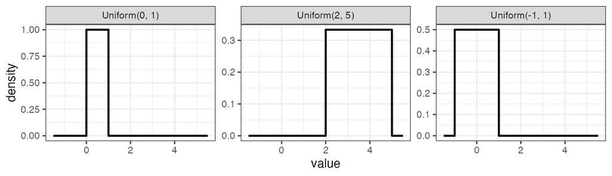

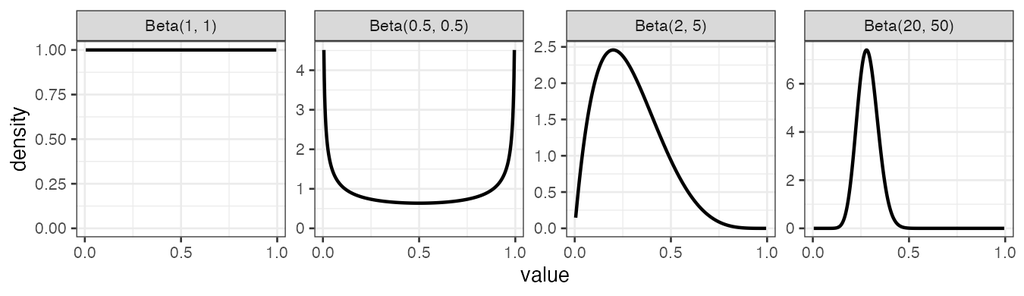

**Writing a quantity that can take one of two forms.** A random variable that takes one of two values other than 0 and 1 can be written using a Bernoulli indicator as an index. For example, if $X_i$ equals $c_1$ with probability $p$ and equals $c_0$ otherwise, where $c_0$ and $c_1$ are fixed numbers, write

$$Z_i\sim\operatorname{Bernoulli}(p),\qquad
X_i=c_{Z_i}.$$

The same idea can choose between two distributions. For example, with

$$Z_i\sim\operatorname{Bernoulli}(p),\qquad X_i\mid
Z_i\sim\operatorname{Normal}(\mu_{Z_i},\sigma^2),$$

$X_i$ is drawn from $\operatorname{Normal}(\mu_1,\sigma^2)$ when $Z_i=1$ and from $\operatorname{Normal}(\mu_0,\sigma^2)$ when $Z_i=0$.